# Project Report

Group-9: Liva Dogan, Kadir Inip, Mehmet Yusuf Kaya

13 02 2021

### 1. Introduction

The goal of this project is to forecast the power demand of next day on hourly basis dates between 29 January 2021 to 12 February 2021. To do that a data set which contains past electricity consumptions and tempreratures for 7 different electricity grids were given on hourly basis dates between 1 January 2017 7 January 2021.

Before deep diving to our forecast first I want to anaylze the parameters and data itself. At first sight it could be concluded that electricity demand is increasing by time, it means that it has trend component. This upward trend might be related to not only increasing electricity usage in our lives but also increasing GDP and population of Turkey with time. In addition to trend seasonality plays a key role to predict elektricity demand. Due to changing temperatute cooling and heating needs changing seasonally. In summers due to cooling demand we observe an increase in power demand. In winters because of heating demand in households we also see an increase in electricity consumption. In springs and autumns demand is relatively low. In our perspective air conditioners is the main reason for summer demand increase while increasing combi usage for winters.

Beside trend and seasonality part, one can observe outliers at first glance. These outliers generally has very low demand compared to regular days. After analysis of these outliers we conclude that these days came across with National and Religious Holidays. We know that these days are national holidays and most of the stores and markets are closed all around the Turkey. Beside these outliers we observed that weekends have lower demand compared to weekdays due to holidays as expected.

By using these market and data analyses, we will plot and observe the data and its parameters. Then we will manipulate the data corresponding to our purposes. After this we will build prediction models and predict the desired day’s consumptions. In addition we will analyze models statistically and finalize our predictions then submit it.

### 2. Data Importing and Manipulations

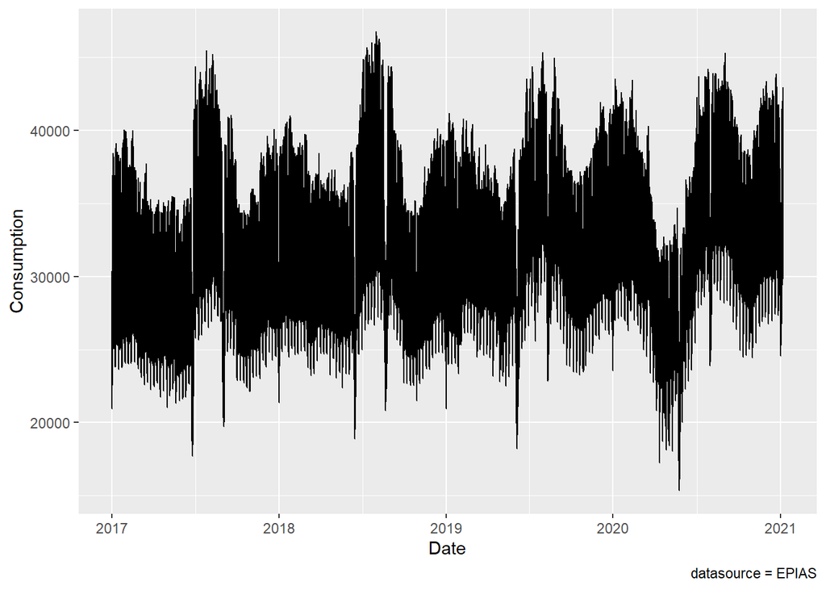

As we observe the general electricity consumption line graph, there are some sharp decreases occuring seasonally. The reason behind the picture is the national and religious days. As the governmental organizations and private companies are closed in that special dates, the electricity consumption decreases significantly for those dates. To be able to use this effect on the model, we should add these dates as columns. However, since the dates of the religious days change year to year, we should add this data manually to the dataset.

It can be observed that the total data has 2 types of seasonality, one of the two is daily seasonality and the other is weekly seasonality. The aim of our model is using both seasonal parts of the data. These can be understood as the hour-of-day effect and day-of-week effect. In order to use the hour-of-day effect, we may group our data by its hour. As an example:

```r
total_consumption0 <- total_consumption[which(event_hour == 0)]
```

After we eliminate the daily seasonality, we achieved more stationary data. However, it is inadequate. To reach more stationary data to build an appropriate arima model, we should take the weekly difference from total consumption data. Let’s proceed total_consumption0 example:

```r
total_consumption0[, WeeklyDiff := consumption - shift(consumption, 7)]
```

### 3. Forecasting with ARIMA Model

Now, our data is stationary enough to build an arima model to forecast future consumption. Instead of using pure arima model, we preffered to use some regressors to develop accuracy of the predictions. As we defined above, we can use the dates of the religious and special days as model regressors. For example model for hour0 is defined as below:

```r
regressor0 <- cbind(total_consumption0$RelDayMond[which(total_consumption0$event_date <
                                                          (max(total_consumption$event_date) - 2))],
                    total_consumption0$RelDayTues[which(total_consumption0$event_date <
                                                          (max(total_consumption$event_date) - 2))],
                    total_consumption0$RelDayWedn[which(total_consumption0$event_date <
                                                          (max(total_consumption$event_date) - 2))],
                    total_consumption0$RelDayThur[which(total_consumption0$event_date <
                                                          (max(total_consumption$event_date) - 2))],
                    total_consumption0$RelDayFrid[which(total_consumption0$event_date <
                                                          (max(total_consumption$event_date) - 2))],
                    total_consumption0$RelDaySatu[which(total_consumption0$event_date <
                                                          (max(total_consumption$event_date) - 2))],
                    total_consumption0$RelDaySund[which(total_consumption0$event_date <
                                                          (max(total_consumption$event_date) - 2))],
                    total_consumption0$SpeDayMond[which(total_consumption0$event_date <
                                                          (max(total_consumption$event_date) - 2))],
                    total_consumption0$SpeDayTues[which(total_consumption0$event_date <
                                                          (max(total_consumption$event_date) - 2))],
                    total_consumption0$SpeDayWedn[which(total_consumption0$event_date <
                                                          (max(total_consumption$event_date) - 2))],
                    total_consumption0$SpeDayThur[which(total_consumption0$event_date <
                                                          (max(total_consumption$event_date) - 2))],
                    total_consumption0$SpeDayFrid[which(total_consumption0$event_date <
                                                          (max(total_consumption$event_date) - 2))],
                    total_consumption0$SpeDaySatu[which(total_consumption0$event_date <
                                                          (max(total_consumption$event_date) - 2))],
                    total_consumption0$SpeDaySund[which(total_consumption0$event_date <
                                                          (max(total_consumption$event_date) - 2))])
arima_model0 = auto.arima(total_consumption0$WeeklyDiff[which(total_consumption0$event_date <
                                                                (max(total_consumption$event_date) - 2))],
                          xreg = regressor0)
```

After building arima model for each hour, we can forecast the future period from using until day d-2. Since we only know the complete data for day d-2 and need to forecast the consumption for day d+1, our forecast() function predicts 3 steps ahead. Furthermore, since there are no special or religious days between the forecasting period, we can assign 0 for these columns.

```r
forecast0 <- forecast(arima_model0, xreg = tail(regressor0, 3), h = 3)
```

As we used difference data for stationarity, we predicted weekly difference for each day. So after performing predictions with our hourly arima models we added our predictions to past data to get actual forecast results.

```r
total_consumption0[event_date < (max(total_consumption$event_date) - 2), Pred_Diff := WeeklyDiff]
total_consumption0[event_date > (max(total_consumption$event_date) - 3), Pred_Diff := forecast0$mean]
total_consumption0[, Forecast := Pred_Diff + shift(consumption, 7)]
```

At the end of the forecasting process, we should combine the data for the latest day and prepare for submission.

```r
final_table <- rbind(tail(total_consumption0, 1), tail(total_consumption1, 1),
                     tail(total_consumption2, 1), tail(total_consumption3, 1),
                     tail(total_consumption4, 1), tail(total_consumption5, 1),
                     tail(total_consumption6, 1), tail(total_consumption7, 1),
                     tail(total_consumption8, 1), tail(total_consumption9, 1),
                     tail(total_consumption10, 1), tail(total_consumption11, 1),
                     tail(total_consumption12, 1), tail(total_consumption13, 1),
                     tail(total_consumption14, 1), tail(total_consumption15, 1),
                     tail(total_consumption16, 1), tail(total_consumption17, 1),
                     tail(total_consumption18, 1), tail(total_consumption19, 1),
                     tail(total_consumption20, 1), tail(total_consumption21, 1),
                     tail(total_consumption22, 1), tail(total_consumption23, 1))

predictions=data.table(Date=rep(as.Date(Sys.time()) + 2,24),Hour=0:23)
predictions=predictions[order(Date,Hour)]
predictions[,forecast:=final_table$Forecast]

send_submission(predictions, token, url=subm_url, submit_now=F)
```

### 4. Forecasting with Simple MA Model

MA model for example hour0:

```r
total_consumption0[, MA2 := (shift(total_consumption0$consumption, 7) + shift(total_consumption0$consumption, 14)) / 2]
```

At the end of the forecasting process, we should combine the data for the latest day and prepare for submission.

```r
final_table <- rbind(tail(total_consumption0, 1), tail(total_consumption1, 1),
                     tail(total_consumption2, 1), tail(total_consumption3, 1),
                     tail(total_consumption4, 1), tail(total_consumption5, 1),
                     tail(total_consumption6, 1), tail(total_consumption7, 1),
                     tail(total_consumption8, 1), tail(total_consumption9, 1),
                     tail(total_consumption10, 1), tail(total_consumption11, 1),
                     tail(total_consumption12, 1), tail(total_consumption13, 1),
                     tail(total_consumption14, 1), tail(total_consumption15, 1),
                     tail(total_consumption16, 1), tail(total_consumption17, 1),
                     tail(total_consumption18, 1), tail(total_consumption19, 1),
                     tail(total_consumption20, 1), tail(total_consumption21, 1),
                     tail(total_consumption22, 1), tail(total_consumption23, 1))

predictions=data.table(Date=rep(as.Date(Sys.time()) + 2,24),Hour=0:23)
predictions=predictions[order(Date,Hour)]
predictions[,forecast:=final_table$MA2]

send_submission(predictions, token, url=subm_url, submit_now=F)
```

### 5. Conclusion and Future Works

And also, in order to improve for both model we should add extra required regressors for instance industry index, the heatmap and temperature values with weigthed average for different regions, the effects of covid term, etc. In a working environment that provides directly access to these data, both models can perform much better than the present case.

Please, check the [RMD file](https://bu-ie-360.github.io/fall20-kadirnp/files/project-rep.Rmd) to reach full-document of the both models.